# Linear Models & Least Squares

INFO 521 · Module 1 · Lecture A — Setup, Data, and the Linear Model

Greg Chism

College of Information Science · University of Arizona

August 2026

## Learning outcomes

By the end of Lecture A you should be able to:

1. **Frame supervised regression** in PML notation — inputs, target, and what we are learning.
2. **Load and preprocess** the NHANES data and **state the leakage rule** for choosing features.
3. **Define** the linear model $\hat{y} = \mathbf{w}^{\!\top}\mathbf{x}$ and the mean-squared-error loss, and **compute $\mathcal{L}$ by hand**.
4. **Fit and interpret** a scalar least-squares line in clinical units.

## The course spine

One clinical outcome — **systolic blood pressure** — seen through **four lenses** this term:

- **Least squares** (Module 1) — fit a line by minimizing squared error.
- **Maximum likelihood** (Module 3) — the same fit, now from a noise model.
- **Bayesian** (later) — carry uncertainty, not just a point estimate.
- **Discovery** (later) — structure and labels we did *not* hand the model.

NHANES recurs in every module so the *methods* change, not the data — you build intuition on one clinical problem.

## Supervised regression

Three kinds of machine learning:

- **Supervised** — learn from **labeled** examples $(\mathbf{x}_n, y_n)$. *Regression* = continuous target; *classification* = discrete labels.
- **Unsupervised** — find structure with **no** labels (clustering, PCA) — the term’s back half.
- **Reinforcement** — learn from a **reward** signal; out of scope here.

**Regression is supervised learning with a continuous target.** Given $(\mathbf{x}_n, y_n)$, learn $f$ so $\hat{y}=f(\mathbf{x})\approx y$ on new $\mathbf{x}$ — here, systolic BP in mmHg.

## Notation & data structures

One example is a vector $\mathbf{x}_n \in \mathbb{R}^{D}$ → one prediction $\hat{y}_n = \mathbf{w}^{\!\top}\mathbf{x}_n$. Stack the dataset:

$$\mathbf{X} = \begin{bmatrix} \text{—}\ \mathbf{x}_1^{\!\top}\ \text{—} \\ \vdots \\ \text{—}\ \mathbf{x}_N^{\!\top}\ \text{—} \end{bmatrix} \in \mathbb{R}^{N \times D},
\qquad
\mathbf{y} = \begin{bmatrix} y_1 \\ \vdots \\ y_N \end{bmatrix} \in \mathbb{R}^{N}.$$

Rows of the **design matrix** $\mathbf{X}$ are patients; $\mathbf{y}$ is the **target vector**. (We write targets $y$ — not $t$.)

## The data — NHANES 2021–2022

- **$N \approx 5{,}102$** U.S. adults; **target** = systolic blood pressure (mmHg).
- **Six leakage-safe features** (the Project-1 design):

| feature | meaning |
| --- | --- |
| `age` | age (years) — the Project-1 primary predictor |
| `bmi` | body-mass index |
| `waist` | waist circumference |
| `chol` | total cholesterol |
| `hdl` | HDL cholesterol |
| `hba1c` | glycated hemoglobin (HbA1c) |

## The leakage rule

**Exclude any predictor that is itself a blood-pressure measurement** — or that would trivially determine the label.

- Diastolic BP (`dbp`) is **reserved**, never a feature: it co-measures the same physiology as the target.
- This is a **by-design** modeling choice, made *before* fitting — not something the algorithm discovers.

## A first look at the data

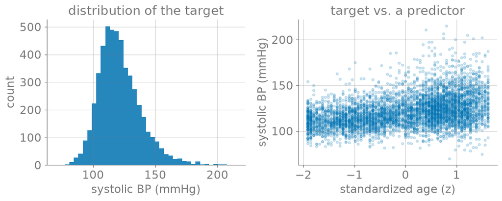

Figure 1: NHANES systolic BP: marginal distribution (left) and vs. standardized age (right).

## The linear model

Predict the target as a weighted sum of the features (with an intercept):

$$\hat{y} \;=\; \mathbf{w}^{\!\top}\mathbf{x} \;=\; w_0 + w_1 x_1 + \cdots + w_D x_D .$$

*(We absorb the intercept by appending a constant-1 feature, so $\mathbf{x}\in\mathbb{R}^{D+1}$.)*

- $w_0$ — the **intercept** (prediction when all features are 0).
- $w_j$ — the **per-unit effect** of feature $j$: how $\hat{y}$ changes when $x_j$ rises by one unit, holding the rest fixed.

## The loss: mean squared error

Measure fit by the average squared miss:

$$\mathcal{L}(\mathbf{w}) \;=\; \tfrac{1}{N}\sum_{n=1}^{N}\bigl(y_n - \mathbf{w}^{\!\top}\mathbf{x}_n\bigr)^2 \;=\; \tfrac{1}{N}\,\lVert \mathbf{y} - \mathbf{X}\mathbf{w}\rVert_2^2 .$$

Why **squared** error? It is **smooth** (differentiable — we’ll set its gradient to zero), and it **penalizes large misses** disproportionately.

A squared loss is also exactly what a Gaussian-noise model gives you — that tie is Module 3.

## Worked: compute $\mathcal{L}$ by hand

Toy data $(x_n, y_n)$: $(0,1),\ (1,1),\ (2,3)$, with a guess $\hat{y}=0.5 + x$.

**Predictions** $\hat{y}_n$: $\;0.5,\ 1.5,\ 2.5$.

**Residuals** $y_n-\hat{y}_n$: $\;0.5,\ -0.5,\ 0.5$.

**Square & average:** $\mathcal{L} = \tfrac{1}{3}\bigl(0.5^2 + (-0.5)^2 + 0.5^2\bigr) = \tfrac{1}{3}(0.75) = 0.25.$

## A scalar least-squares fit

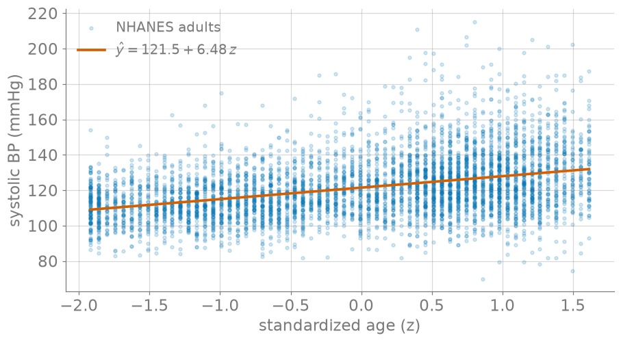

Figure 2: Least-squares fit of systolic BP on standardized age.

## Interpreting the fit

The fitted line is $\hat{y} = \hat{w}_0 + \hat{w}_1 z$ with $\hat{w}_0 \approx 121.5$, $\hat{w}_1 \approx 6.5$ (mmHg per **standard deviation** of age).

- **Intercept** $\hat{w}_0$: predicted SBP at *average* age (where $z=0$) — about **121.5 mmHg**, a clinically sensible central value.
- **Slope** $\hat{w}_1$: $+1$ SD of age ($\approx 17$ years) adds $\approx 6.5$ mmHg, i.e. **$\approx 0.38$ mmHg per year**.
- **Sanity check** — sign is positive (BP rises with age) and the magnitude is modest and plausible. Always translate weights back to units.

## Live demo: the least-squares explorer

Drag the line, watch the loss respond — the tool is live on this slide.

## Explorer — static fallback

*The iframe above does not print or export to PDF; this snapshot stands in.*

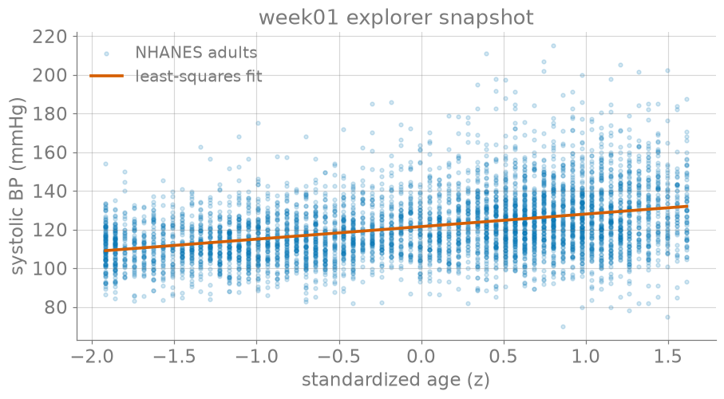

Figure 3: Static fallback snapshot of the week01 least-squares explorer.

## Recap & bridge

We now have the two ingredients of least squares:

- a **model** — $\hat{y} = \mathbf{w}^{\!\top}\mathbf{x}$, and
- a **loss** — $\mathcal{L}(\mathbf{w}) = \tfrac{1}{N}\lVert\mathbf{y}-\mathbf{X}\mathbf{w}\rVert_2^2$.

**Next (Lecture B):** solve for the best $\mathbf{w}$ in closed form — set the gradient to zero — and see the geometry behind it.